# Risperidone effects on liver function in children: A systematic review & metaanalysis

2022-01-23 09:14:50

### Introduction

Risperidone is the most well known second generation antipsychotic drugs. It has been extensively studied, both in adults and pediatrics population. In children, it has been used to treat wide variety of behavioral dan sexual disorder. Along with the other newer antipsychotic drugs, risperidone had documented fewer side effects and an overall better safety profile. Although it has been favored as oral dopamine antagonist, it notoriusly known for its metabolic effects particularly the weight promoting and insulin resistance effects. Less attention were given to the liver damage due to antipsychotic. There are rather sporadic reports published about the hepatocellular damage of risperidone. This study aimed to estimate the overall liver function changes after risperidone treatment for behavioral disorder in children.

### Methods

#### Search strategy and study inclusion

This systematic review and metaanalysis gathered the available evidence from various online journal database including PubMed, Cochrane Library, EuropePMC, Google Scholar, Lens.org, and Dimensions which published until Januari 2022. The initial keywords used for the search included “risperidon,” “liver function,” “liver enzyme” and the possible synonym. In addition, we manually searched review articles and checked reference lists for studies that might have been missed from the electronic search. The meta-analysis was conducted and reported based on Preferred Items for Systematic Reviews and Meta-analysis (PRISMA) guidelines. The inclusion criteria were (a) original studies published in English language journals, reporting data on liver function before and after treatment with risperidone; (b) observational studies; and (c) human studies on individuals aged less than 18 years. We excluded review papers, case series or case reports, studies on adults, and animal studies. Two authors (VLW and KAW) independently identified suitable articles according to the above criteria. The disparity in opinion on whether studies should be included in the analysis were resolved by discussion and input from the third reviewers (AFL).

#### Data extraction and synthesis

Data extraction was done independently each author. For each study, we extracted data including authors, journal, year of publication, study design, age group, gender, number of participants, and weight changes. If more than one paper with the same data or results from similar study were identified, only the one that accommodated the definitive data was included.

### Results

There were 8 literature included in this study (Szigethy et al. 1999; Erdogan et al. 2008, 2010; Karaman et al. 2011; Margari et al. 2013; Kowatch et al. 2015; Scahill et al. 2016; Baeza et al. 2018). All studies include SGPT values, while only 7 had SGOT values.

```r
datatable(data[order(data$Year),],
          options = list(pageLength=50,
                         scrollX='400px'),
          filter = 'top')
```

|  | First_author | Year | Age(years) | Comparison | Dose | Duration | N_post_SGOT | Mean_post_SGOT | SD_post_SGOT | N_control | Mean_control | SD_control | Journal | N_post_SGPT | Mean_post_SGPT | SD_post_SGPT | N_pre_SGPT | Mean_pre_SGPT | SD_pre_SGPT |
| --- | --- | --- | --- | --- | --- | --- | --- | --- | --- | --- | --- | --- | --- | --- | --- | --- | --- | --- | --- |
| 1 | Szigethy | 1999 | 5-17 | After vs Before | 0.5-6 mg/day | 1-35 Months | 38 | 26.84 | 8.04 | 38 | 30.46 | 12.45 | https://drive.google.com/file/d/1uwwi3ZszEE1PRVVvM8y4CFXG7CJ63276/view?usp=sharing | 38 | 23 | 8.8 | 38 | 18.55 | 11.6 |
| 2 | Erdogan | 2008 | 3-17 | After vs Before |  | 4 weeks | 63 | 27.2 | 7.2 | 63 | 14.3 | 5.6 | https://drive.google.com/file/d/1pu9Zs2joQoxJX57GaeymwoL87W3qs8oe/view?usp=sharing | 63 | 16.2 | 10 | 63 | 11.5 | 2.8 |
| 3 | Erdogan | 2010 |  | After vs Before | 0.25-6 mg/day | 6 months or more | 45 | 28 | 7.4 | 45 | 16 | 4.2 | https://drive.google.com/file/d/1dm2_torOz7iugjB4ydAjkexNM43k-Cv8/view?usp=sharing | 45 | 16 | 4.2 | 45 | 12 | 2.6 |
| 4 | Karaman | 2011 | 3-18 | After vs Before |  | 12 Months | 100 | 26.78 | 7.01 | 100 | 17.05 | 7.3 | https://drive.google.com/file/d/1ED74zuOrtSrPl73BfHhf2r3sthnQ3QsC/view?usp=sharing | 100 | 17.22 | 5.5 | 100 | 12.33 | 3.38 |
| 5 | Margari | 2013 | 6-17 | After vs Before | 0.25-4 mg/day | 3-12 Months | 22 | 24.6 | 9 | 22 | 22.5 | 6.5 | https://drive.google.com/file/d/1QnQVhg1QmCc1TskGpu9lcv2XGE8y1Izq/view?usp=sharing | 22 | 33.8 | 5.23 | 22 | 30.5 | 6.4 |
| 6 | Kowatch | 2015 | 3-7 | After vs Before |  | 6 weeks | 18 | 58.5 | 15.3 | 18 | 49 | 10 | https://drive.google.com/file/d/1hgjHCx5py7ZB8Lf2YMpIR9KBCcCtlmF-/view?usp=sharing | 18 | 23.4 | 9.2 | 18 | 20.3 | 9 |
| 7 | Schaill | 2016 | 4-14 | After vs Before | 1.75 - 3.5 mg/day. | 16 Weeks |  |  |  |  |  |  | https://drive.google.com/file/d/1wRReKHXUM1fNPy_V22CvvOoXm07_pJTI/view?usp=sharing | 88 | 20.7 | 11.2 | 86 | 17.8 | 6.8 |
| 8 | Baeza | 2018 | 4-17 | After vs Before |  | 12 Months | 67 | 22.6 | 5.5 | 216 | 23.5 | 7 | https://drive.google.com/file/d/1jVlKXFcgCqUYMU3nEHTy0OPZdU5VMPHM/view?usp=sharing | 67 | 17.4 | 9.3 | 216 | 18 | 12.9 |

#### Forest plot of SGOT Changes before and after treatment of risperidone

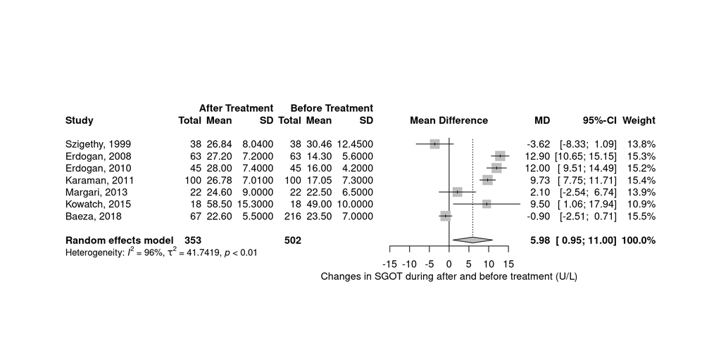

```r
data1 <- data[2:8,]
sgot <- metacont(n.e = data1$N_post_SGOT,
                 mean.e = data1$Mean_post_SGOT,
                 sd.e = data1$SD_post_SGOT,
                 n.c = data1$N_control,
                 mean.c = data1$Mean_control,
                 sd.c = data1$SD_control,
                 studlab = paste0(data1$First_author, ", " ,data1$Year))

forest(sgot,
       xlab="Changes in SGOT during after and before treatment (U/L)",
       sortvar = data1$Year,
       smlab = "Mean Difference",
       lab.e = "After Treatment",
       lab.c = "Before Treatment",
       fixed = FALSE)
```

#### Forest plot of SGPT Changes before and after treatment of risperidone

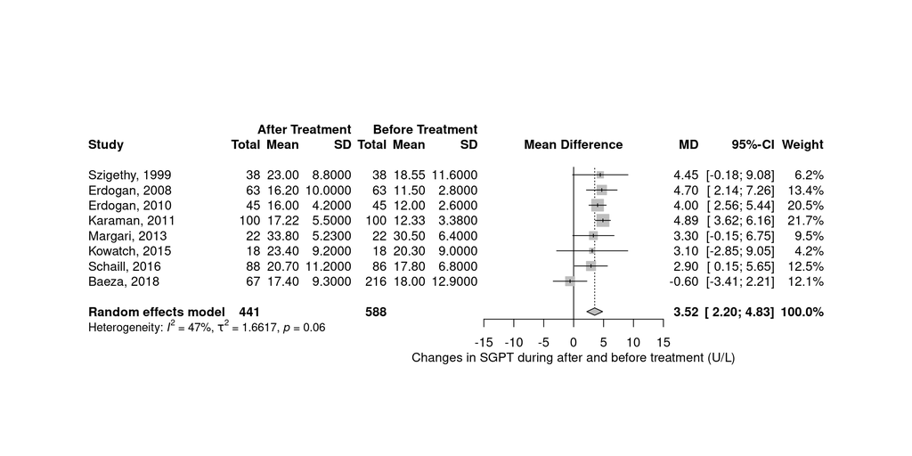

```r
data2 <- data
sgpt <- metacont(n.e = data2$N_post_SGPT,
                 mean.e = data2$Mean_post_SGPT,
                 sd.e = data2$SD_post_SGPT,
                 n.c = data2$N_pre_SGPT,
                 mean.c = data2$Mean_pre_SGPT,
                 sd.c = data2$SD_pre_SGPT,
                 studlab = paste0(data2$First_author, ", " ,data2$Year))

forest(sgpt,
       xlab="Changes in SGPT during after and before treatment (U/L)",
       xlim = c(-15,15),
       sortvar = data2$Year,
       smlab = "Mean Difference",
       lab.e = "After Treatment",
       lab.c = "Before Treatment",
       fixed = FALSE)
```

#### Risk of publication Bias (Funnel Plot)

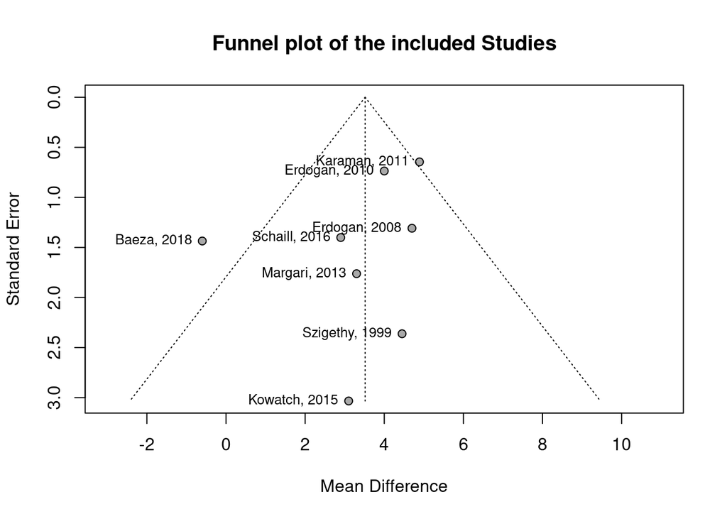

```r
funnel.meta(sgpt,
            xlim = c(-3,11),
            studlab = TRUE,
            random = TRUE,
            fixed = FALSE)
title("Funnel plot of the included Studies")
```

### Conclusion

Risperidone administration in children for behavioral disorder results in increased level of liver enzyme (SGOT SGPT). However, such increase were rather minor and does not translate to any clinically meaningful consequences.

### References

Baeza, Inmaculada, Elena de la Serna, Rosa Calvo-Escalona, Jessica Merchán-Naranjo, Pamela Rodríguez-Latorre, M. Carmen Martínez-Cantarero, Patricia Andrés, et al. 2018. “One-Year Prospective Study of Liver Function Tests in Children and Adolescents on Second-Generation Antipsychotics: Is There a Link with Metabolic Syndrome?” *Journal of Child and Adolescent Psychopharmacology* 28 (7): 463–73. https://doi.org/10.1089/cap.2017.0117.

Balduzzi, Sara, Gerta Rücker, and Guido Schwarzer. 2019. “How to Perform a Meta-Analysis with R: A Practical Tutorial.” *Evidence-Based Mental Health*, no. 22: 153–60.

Bryan, Jennifer. 2021. *Googlesheets4: Access Google Sheets Using the Sheets API V4*. https://CRAN.R-project.org/package=googlesheets4.

Canonical. 2021. “Ubuntu Server.” London. https://wiki.ubuntu.com/FocalFossa/ReleaseNotes?_ga=2.202901329.1166669392.1642903327-1244252401.1642903327.

Erdogan, Ayten, Nuray Atasoy, Hanife Akkurt, Devrim Ozturk, Elif Karaahmet, Irem Yalug, Kivanc Yalug, Handan Ankarali, and Ibrahim Balcioglu. 2008. “Risperidone and Liver Function Tests in Children and Adolescents: A Short-Term Prospective Study.” *Progress in Neuro-Psychopharmacology & Biological Psychiatry* 32 (3): 849–57. https://doi.org/10.1016/j.pnpbp.2007.12.032.

Erdogan, Ayten, Mehmet Goksin Karaman, Esra Ozdemir, Nihal Yurteri, Ali Evren Tufan, and Mehmet Ali Kurcer. 2010. “Six Months of Treatment with Risperidone May Be Associated with Nonsignificant Abnormalities of Liver Function Tests in Children and Adolescents: A Longitudinal, Observational Study from Turkey.” *Journal of Child and Adolescent Psychopharmacology* 20 (5): 407–13. https://doi.org/10.1089/cap.2009.0113.

Haddaway, Neal R, Chris C Pritchard, and Luke A McGuinness. 2021. *Prisma2020: R Package and ShinyApp for Producing PRISMA 2020 Compliant Flow Diagrams (Version 0.0.2)*. https://doi.org/10.5281/zenodo.5082518.

Higgins, JPT, J Thomas, J Chandler, M Cumpston, MJ Page, and VA Welch. 2021. *Cochrane Handbook for Systematic Reviews of Interventions Version 6.2 (Updated February 2021)*. Cochrane. www.training.cochrane.org/handbook.

Karaman, Mehmet Gökşin, Ayten Erdoğan, Evren Tufan, Nihal Yurteri, Esra Ozdemir, and Handan Ankarali. 2011. “Liver Function Tests in Children and Adolescents Receiving Risperidone Treatment for a Year: A Longitudinal, Observational Study from Turkey.” *International Journal of Psychiatry in Clinical Practice* 15 (3): 204–8. https://doi.org/10.3109/13651501.2011.582537.

Kowatch, Robert A., Russell E. Scheffer, Erin Monroe, Sergio Delgado, Mekibib Altaye, and Denise Lagory. 2015. “Placebo-Controlled Trial of Valproic Acid Versus Risperidone in Children 3-7 Years of Age with Bipolar I Disorder.” *Journal of Child and Adolescent Psychopharmacology* 25 (4): 306–13. https://doi.org/10.1089/cap.2014.0166.

Margari, Lucia, Emilia Matera, Francesco Craig, Maria G. Petruzzelli, Vincenzo O. Palmieri, Adriana Pastore, and Francesco Margari. 2013. “Tolerability and Safety Profile of Risperidone in a Sample of Children and Adolescents.” *International Clinical Psychopharmacology* 28 (4): 177–83. https://doi.org/10.1097/YIC.0b013e328362497b.

R Core Team. 2021. *R: A Language and Environment for Statistical Computing*. Vienna, Austria: R Foundation for Statistical Computing. https://www.R-project.org/.

Rstudio. 2021. “RStudio: Integrated Development for R.” Boston: Rstudio PBC. http://www.rstudio.com/.

Scahill, Lawrence, Sangchoon Jeon, Susan J. Boorin, Christopher J. McDougle, Michael G. Aman, James Dziura, James T. McCracken, et al. 2016. “Weight Gain and Metabolic Consequences of Risperidone in Young Children With Autism Spectrum Disorder.” *Journal of the American Academy of Child and Adolescent Psychiatry* 55 (5): 415–23. https://doi.org/10.1016/j.jaac.2016.02.016.

Sjoberg, Daniel D., Karissa Whiting, Michael Curry, Jessica A. Lavery, and Joseph Larmarange. 2021. “Reproducible Summary Tables with the Gtsummary Package.” *The R Journal* 13: 570–80. https://doi.org/10.32614/RJ-2021-053.

Szigethy, E., M. Wiznitzer, L. A. Branicky, K. Maxwell, and R. L. Findling. 1999. “Risperidone-Induced Hepatotoxicity in Children and Adolescents? A Chart Review Study.” *Journal of Child and Adolescent Psychopharmacology* 9 (2): 93–98. https://doi.org/10.1089/cap.1999.9.93.

Wickham, Hadley, Mara Averick, Jennifer Bryan, Winston Chang, Lucy D’Agostino McGowan, Romain François, Garrett Grolemund, et al. 2019. “Welcome to the tidyverse.” *Journal of Open Source Software* 4 (43): 1686. https://doi.org/10.21105/joss.01686.

Xie, Yihui, Joe Cheng, and Xianying Tan. 2021. *DT: A Wrapper of the JavaScript Library ’DataTables’*. https://CRAN.R-project.org/package=DT.

#### Software (session info)

```r
print("Analysis run by: Kadek Adit Wiryadana (wiryadana@wiryadana.org)")
```

```
## [1] "Analysis run by: Kadek Adit Wiryadana (wiryadana@wiryadana.org)"
```

```bash
cp Risperidon_bodyweight.html index.html
```